# Mucosal microbiota alterations in primary sclerosis cholangitis persist after liver transplantation and are associated with clinical features independently of geography

Additional disease control

# 1 Introduction

**PSC vs ALD**

In previous analyses, we showed specific mucosal composition in PSC patients which persist after liver transplantation. Here, we added another positive control, to explore if this condition is disease specific, or it can be credited to (liver) disease in general.

Fo this purpose, we conduct the univariate analysis on Czech ALD patients after LTx. By comparing post_LTx PSC and ALD patients, we can check if the proposed PSC-associated bacteria are at least partially overlapping.

If so, this would confirm our previous conclusions that these bacteria are specific for PSC.

**Importing libraries and custom functions built for this analysis**

```r
source("custom_functions.R")
```

# 2 Data Import

Importing ASV, taxa and metadata tables for both Czech ALD samples samples.

```r
path = "../../data/analysis_ready_data/ikem/ALD/"
asv_tab_ALD <- as.data.frame(fread(file.path(path,"asv_table_ALD.tsv"),
                                    check.names = FALSE))
taxa_tab_ALD <- as.data.frame(fread(file.path(path,"taxa_table_ALD.tsv"),
                                     check.names = FALSE))
metadata_ALD <- as.data.frame(fread(file.path(path,"metadata_ALD.tsv"),
                                     check.names = FALSE))
```

Importing previous Czech dataset with PSC patients.

```r
path = "../../data/analysis_ready_data/ikem/"
asv_tab_ikem <- as.data.frame(fread(file.path(path,"asv_table_ikem.csv"),
                                    check.names = FALSE))
taxa_tab_ikem <- as.data.frame(fread(file.path(path,"taxa_table_ikem.csv"),
                                     check.names = FALSE))
metadata_ikem <- as.data.frame(fread(file.path(path,"metadata_ikem.csv"),
                                     check.names = FALSE))
```

Importing proposed PSC-associated taxa.

```r
psc_genus_ti <- read.xlsx("../results/Q1/univariate_analysis/supplements_psc_effect_terminal_ileum.xlsx",
                     sheet = "terminal_ileum genus")

psc_genus_colon <- read.xlsx("../results/Q1/univariate_analysis/supplements_psc_effect_colon.xlsx",
                     sheet = "colon genus")
```

# 3 Terminal ileum

```r
segment="TI"

ileum_data <- merging_data(asv_tab_1=asv_tab_ALD,
                           asv_tab_2=asv_tab_ikem,
                           taxa_tab_1=taxa_tab_ALD,
                           taxa_tab_2=taxa_tab_ikem,
                           metadata_1=metadata_ALD,
                           metadata_2=metadata_ikem,
                           segment=segment,Q="QALD")
```

```
Removing 630 ASV(s)
```

```
Removing 1498 ASV(s)
```

```
Merging at ASV level
```

```
Finding inconsistencies in taxonomy, trying to keep the ones that have better taxonomy assignment
```

```
Removing 223 ASV(s)
```

```r
ileum_asv_tab <- ileum_data[[1]]
ileum_taxa_tab <- ileum_data[[2]]
ileum_metadata <- ileum_data[[3]]
```

## 3.1 Univariate Analysis

Similar to previous approaches, we will use two DAA tools - linDA and Maaslin. Only the intersection of sets selected by each tool are shown to minimize false positives. As this analysis can only be conducted on Czech cohort, no interaction effect can be shown, therefore only Group effect is investigated.

This analysis is performed at genus level only.

```r
level="genus"

# needed paths
path = "../results/QALD/univariate_analysis"
path_maaslin=file.path("../intermediate_files/maaslin/QALD",level)
```

```r
# variables
raw_linda_results_genus <- list();
raw_linda_results_genus[[segment]] <- list()
linda_results_genus <- list();
linda_results_genus[[segment]] <- list()

# country and interaction problems
list_country_union <- list()
list_intersections <- list()
list_venns <- list()
uni_statistics <- list()

# workbook for final df
wb <- createWorkbook()
```

Aggregate taxa

```r
genus_data <- aggregate_taxa(ileum_asv_tab,
                             ileum_taxa_tab,
                             taxonomic_level = level)

ileum_genus_tab <- genus_data[[1]]
ileum_genus_taxa_tab <- genus_data[[2]]

ileum_genus_asv_taxa_tab <- create_asv_taxa_table(ileum_genus_tab,
                                                  ileum_genus_taxa_tab)
```

### 3.1.1 PSC vs ALD

We can assume, that the differentially abundant taxa between these two groups are caused by PSC disease and other factors, like liver cirrhosis and overall bad clinical condition.

```r
group <- c("ALD post_ltx","PSC post_ltx")
comparison_name <- paste0(group[1], " vs ",group[2])
```

#### 3.1.1.1 linDA

```r
# prepare the data
linda_data <- binomial_prep(ileum_genus_tab,
                            ileum_genus_taxa_tab,
                            ileum_metadata,
                            group, usage="linDA")
```

```
Removing 33 ASV(s)
```

```r
filt_ileum_uni_data <- linda_data[[1]]
filt_ileum_uni_taxa <- linda_data[[2]]
filt_ileum_uni_metadata <- linda_data[[3]]

# fit the model
linda.obj <- linda(filt_ileum_uni_data,
                   filt_ileum_uni_metadata,
                   formula = '~ Group')
```

```
0  features are filtered!
The filtered data has  144  samples and  200  features will be tested!
Pseudo-count approach is used.
Fit linear models ...
Completed.
```

```r
linda.output <- linda.obj$output
linda.output <- linda_renaming(linda.output, group)

# save the results
group1 <- paste0(group[1], " vs ","Group",group[2])

for (grp in c(group1)){
  raw_linda_results_genus[[segment]][[grp]] <-
    rawlinda.df(linda.output,
                grp,
                filt_ileum_uni_data,
                filt_ileum_uni_taxa)

  linda_results_genus[[segment]][[grp]] <-
    linda.df(linda.output,
             grp,
             filt_ileum_uni_data,
             filt_ileum_uni_taxa)
}
```

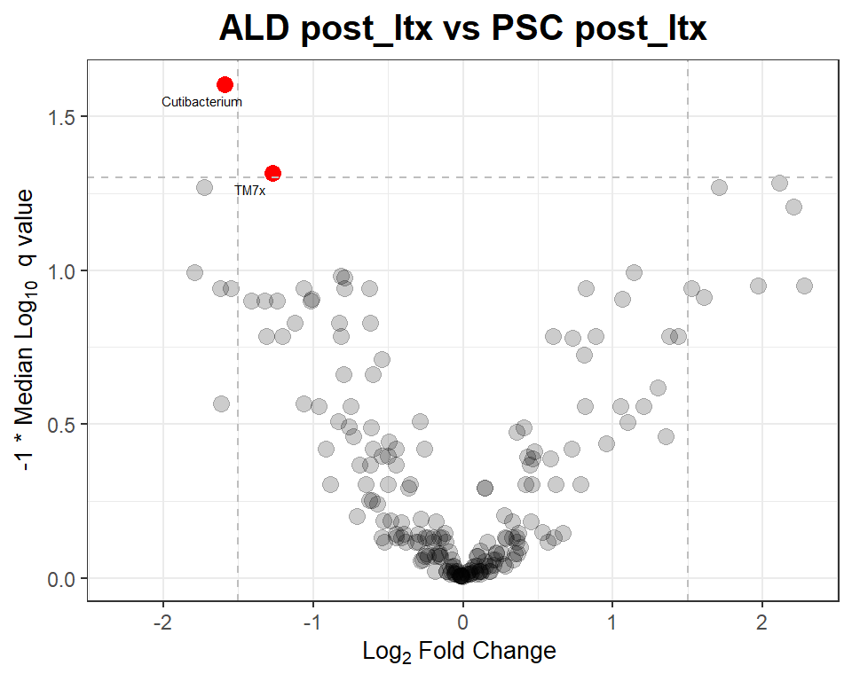

```r
# volcano plots
volcano <- volcano_plot_linda(linda.output,
                                group1,
                                taxa_table = filt_ileum_uni_taxa) +
            ggtitle(comparison_title)

volcano
```

#### 3.1.1.2 MaAsLin2

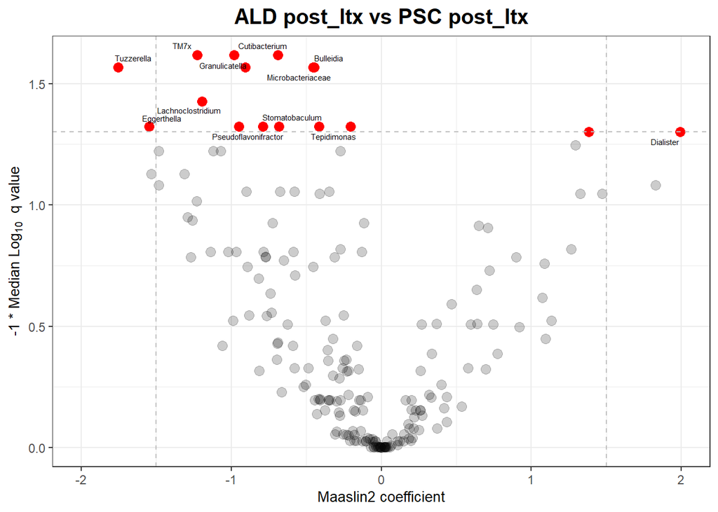

```r
volcano <- volcano_plot_maaslin(fit_data,filt_ileum_uni_taxa) +
            ggtitle(comparison_title)


volcano
```

#### 3.1.1.3 Group - Intersection

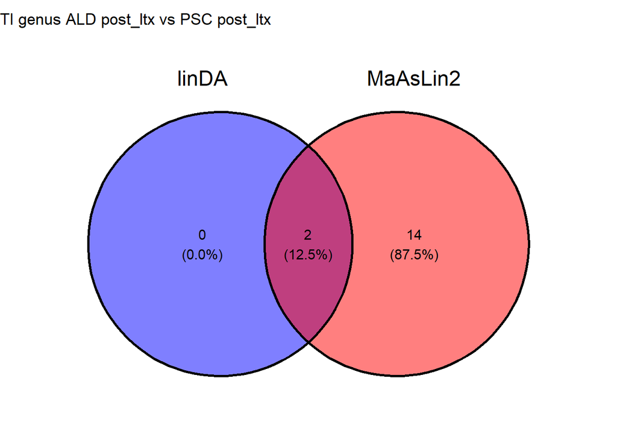

```r
intersection_results <- group_intersection(group, list_intersections, list_venns,
                                           linda.output, fit_data,
                                           raw_linda_results_genus,
                                           segment = segment,
                                           level=level)

list_intersections <- intersection_results[[1]]
list_venns <- intersection_results[[2]]
venn <- intersection_results[[3]]

# show the results
venn
```

#### 3.1.1.4 Basic statistics

```r
uni_df <-  merge(basic_univariate_statistics(linda_data,group),
                 raw_linda_results_genus[[segment]][[group1]],
                 by="SeqID",all=TRUE)
```

```
[1] "ALD post_ltx"
[1] "PSC post_ltx"
[1] "ALD post_ltx"
[1] "PSC post_ltx"
```

```r
uni_df[["final_sig"]] <- uni_df$SeqID %in% list_intersections[[paste(segment,level,comparison_name)]][["SeqID"]]
uni_statistics[[segment]][[paste(level,comparison_name)]] <- uni_df

# for comparison
new_name <- comparison_name
addWorksheet(wb, sheetName = new_name)
writeData(wb, sheet = new_name, uni_df, rowNames=FALSE)
```

#### 3.1.1.5 Comparison with PSC-associated taxa

```r
psc_ald_sig_ti <- uni_df %>%
  dplyr::filter(final_sig==TRUE) %>%
  dplyr::select(SeqID,Taxonomy,log2FoldChange)

psc_genus_ti <- psc_genus_ti
```

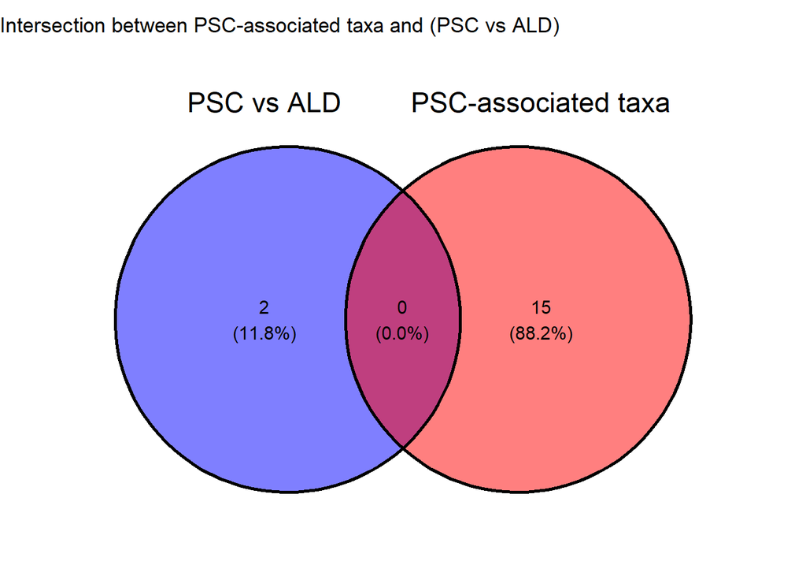

```r
list_core <- list()
list_core[["PSC vs ALD"]] <- psc_ald_sig_ti$Taxonomy
list_core[["PSC-associated taxa"]] <- psc_genus_ti$Taxonomy

# venn diagram
venn <- ggvenn(list_core, fill_color = c("blue", "red")) +
    ggtitle("Intersection between PSC-associated taxa and (PSC vs ALD)") +
    guides(fill = "none")

venn
```

```r
intersection_df <- intersect(list_core$`PSC vs ALD`,list_core$`PSC-associated taxa`)

intersection_df
```

```
character(0)
```

### 3.1.2 ALD vs HC

```r
group <- c("HC","ALD post_ltx")
comparison_name <- paste0(group[1], " vs ",group[2])
```

#### 3.1.2.1 linDA

```r
# prepare the data
linda_data <- binomial_prep(ileum_genus_tab,
                            ileum_genus_taxa_tab,
                            ileum_metadata,
                            group, usage="linDA")
```

```
Removing 82 ASV(s)
```

```r
filt_ileum_uni_data <- linda_data[[1]]
filt_ileum_uni_taxa <- linda_data[[2]]
filt_ileum_uni_metadata <- linda_data[[3]]

# fit the model
linda.obj <- linda(filt_ileum_uni_data,
                   filt_ileum_uni_metadata,
                   formula = '~ Group')
```

```
0  features are filtered!
The filtered data has  79  samples and  216  features will be tested!
```

```
Pseudo-count approach is used.
Fit linear models ...
Completed.
```

```r
linda.output <- linda.obj$output
linda.output <- linda_renaming(linda.output, group)

# save the results
group1 <- paste0(group[1], " vs ","Group",group[2])

for (grp in c(group1)){
  raw_linda_results_genus[[segment]][[grp]] <-
    rawlinda.df(linda.output,
                grp,
                filt_ileum_uni_data,
                filt_ileum_uni_taxa)

  linda_results_genus[[segment]][[grp]] <-
    linda.df(linda.output,
             grp,
             filt_ileum_uni_data,
             filt_ileum_uni_taxa)
}
```

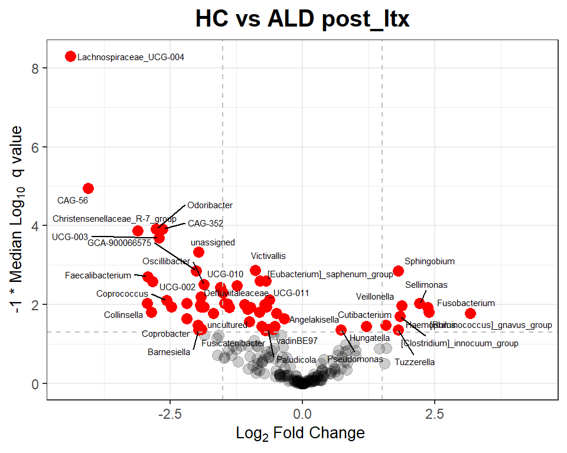

```r
# volcano plots
volcano <- volcano_plot_linda(linda.output,
                                group1,
                                taxa_table = filt_ileum_uni_taxa) +
            ggtitle(comparison_title)

volcano
```

#### 3.1.2.2 MaAsLin2

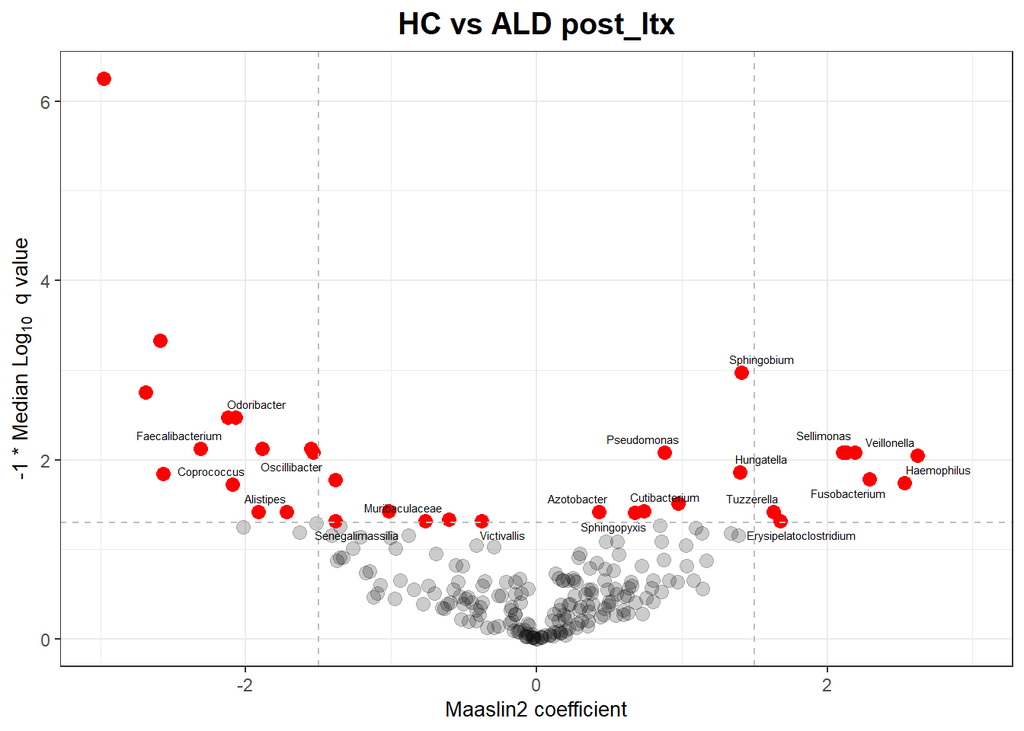

```r
volcano <- volcano_plot_maaslin(fit_data,filt_ileum_uni_taxa) +
            ggtitle(comparison_title)


volcano
```

#### 3.1.2.3 Group - Intersection

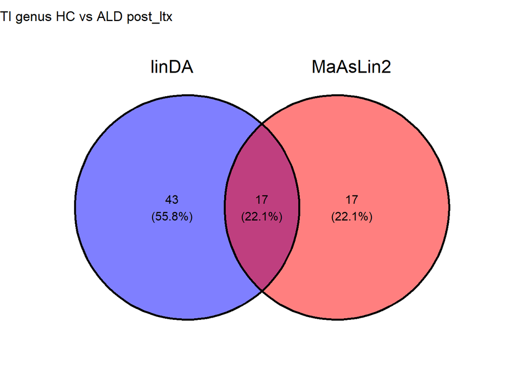

```r
intersection_results <- group_intersection(group, list_intersections, list_venns,
                                           linda.output, fit_data,
                                           raw_linda_results_genus,
                                           segment = segment,
                                           level=level)

list_intersections <- intersection_results[[1]]
list_venns <- intersection_results[[2]]
venn <- intersection_results[[3]]

# show the results
venn
```

#### 3.1.2.4 Basic statistics

```r
uni_df <-  merge(basic_univariate_statistics(linda_data,group),
                 raw_linda_results_genus[[segment]][[group1]],
                 by="SeqID",all=TRUE)
```

```
[1] "HC"
[1] "ALD post_ltx"
[1] "HC"
[1] "ALD post_ltx"
```

```r
uni_df[["final_sig"]] <- uni_df$SeqID %in% list_intersections[[paste(segment,level,comparison_name)]][["SeqID"]]
uni_statistics[[segment]][[paste(level,comparison_name)]] <- uni_df

# for comparison
new_name <- comparison_name
addWorksheet(wb, sheetName = new_name)
writeData(wb, sheet = new_name, uni_df, rowNames=FALSE)
```

#### 3.1.2.5 Comparison with PSC-associated taxa

```r
hc_ald_sig_ti <- uni_df %>%
  dplyr::filter(final_sig==TRUE) %>%
  dplyr::select(SeqID,Taxonomy,log2FoldChange)

psc_genus_ti <- psc_genus_ti
```

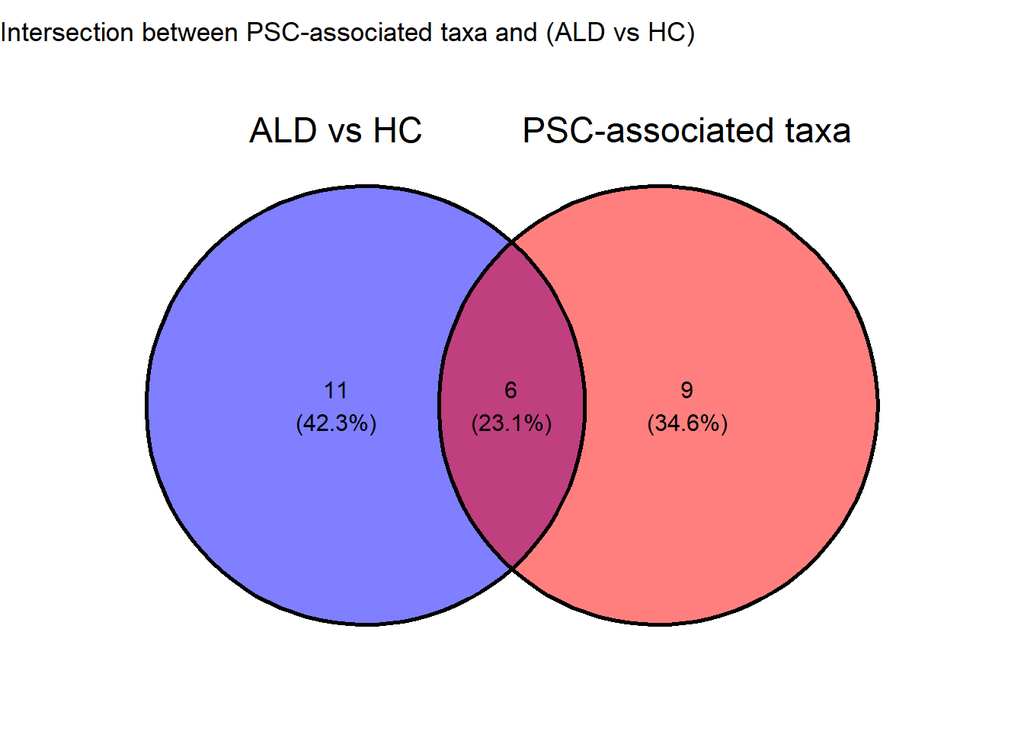

```r
list_core <- list()
list_core[["ALD vs HC"]] <- hc_ald_sig_ti$Taxonomy
list_core[["PSC-associated taxa"]] <- psc_genus_ti$Taxonomy

# venn diagram
venn <- ggvenn(list_core, fill_color = c("blue", "red")) +
    ggtitle("Intersection between PSC-associated taxa and (ALD vs HC)") +
    guides(fill = "none")

venn
```

From this Venn diagram, we are interested in EXLUSIVE RIGH JOIN

```r
A <- list_core$`ALD vs HC`
B <- list_core$`PSC-associated taxa`
remaining_psc <- B[!(B %in% A)]

psc_genus_ti %>%
  dplyr::filter(Taxonomy %in% remaining_psc)
```

```
                         SeqID
1                Enterorhabdus
2                  Barnesiella
3                Butyricimonas
4              Parabacteroides
5                   Holdemania
6             Fusicatenibacter
7            Lachnoclostridium
8 Lachnospiraceae_FCS020_group
9                 Enterococcus
                                                                                                      Taxonomy
1    k__Bacteria;p__Actinobacteriota;c__Coriobacteriia;o__Coriobacteriales;f__Eggerthellaceae;g__Enterorhabdus
2                k__Bacteria;p__Bacteroidota;c__Bacteroidia;o__Bacteroidales;f__Barnesiellaceae;g__Barnesiella
3               k__Bacteria;p__Bacteroidota;c__Bacteroidia;o__Bacteroidales;f__Marinifilaceae;g__Butyricimonas
4             k__Bacteria;p__Bacteroidota;c__Bacteroidia;o__Bacteroidales;f__Tannerellaceae;g__Parabacteroides
5              k__Bacteria;p__Firmicutes;c__Bacilli;o__Erysipelotrichales;f__Erysipelotrichaceae;g__Holdemania
6             k__Bacteria;p__Firmicutes;c__Clostridia;o__Lachnospirales;f__Lachnospiraceae;g__Fusicatenibacter
7            k__Bacteria;p__Firmicutes;c__Clostridia;o__Lachnospirales;f__Lachnospiraceae;g__Lachnoclostridium
8 k__Bacteria;p__Firmicutes;c__Clostridia;o__Lachnospirales;f__Lachnospiraceae;g__Lachnospiraceae_FCS020_group
9                   k__Bacteria;p__Firmicutes;c__Bacilli;o__Lactobacillales;f__Enterococcaceae;g__Enterococcus
  log2FoldChange      p_value         padj
1      -1.050549 1.087023e-02 4.545734e-02
2      -3.177161 1.263665e-03 7.750481e-03
3      -2.900425 6.571752e-05 9.301556e-04
4      -3.418185 1.366753e-05 2.794251e-04
5      -1.213660 1.082333e-02 4.545734e-02
6      -2.864295 5.224510e-04 4.336862e-03
7      -1.781011 1.555333e-03 9.231654e-03
8      -2.231945 8.971276e-04 6.113758e-03
9       4.892498 4.554602e-10 8.380467e-08
```

```r
uni_df %>%
  dplyr::filter(Taxonomy %in% remaining_psc)
```

```
                         SeqID  Q1_clr HC Q1_clr ALD post_ltx     Q1_ra HC
1                  Barnesiella  2.2306841           -1.154492 0.0008978388
2                Butyricimonas  0.4732196           -1.336010 0.0001128859
3                 Enterococcus -1.8330261           -1.727812 0.0000000000
4                Enterorhabdus -1.5823853           -1.727812 0.0000000000
5             Fusicatenibacter  2.4909696           -0.227097 0.0015781761
6                   Holdemania -1.5163636           -1.717373 0.0000000000
7            Lachnoclostridium  4.5353883            4.487578 0.0166991131
8 Lachnospiraceae_FCS020_group  0.3961494           -1.526367 0.0001974724
9              Parabacteroides  3.4409794            0.750685 0.0033754974
  Q1_ra ALD post_ltx MEDIAN_clr HC MEDIAN_clr ALD post_ltx MEDIAN_clr_ALL
1       0.0000000000      3.390671               2.2487867      3.0290037
2       0.0000000000      1.642021               0.3369299      1.1642191
3       0.0000000000     -1.582385              -1.3920182     -1.5512393
4       0.0000000000     -1.233676              -1.3572043     -1.3225254
```

[output cut: 75 more lines]

# 4 Colon

```r
segment="colon"

colon_data <- merging_data(asv_tab_1=asv_tab_ALD,
                           asv_tab_2=asv_tab_ikem,
                           taxa_tab_1=taxa_tab_ALD,
                           taxa_tab_2=taxa_tab_ikem,
                           metadata_1=metadata_ALD,
                           metadata_2=metadata_ikem,
                           segment=segment,Q="QALD")
```

```
Removing 158 ASV(s)
```

```
Removing 739 ASV(s)
```

```
Merging at ASV level
```

```
Finding inconsistencies in taxonomy, trying to keep the ones that have better taxonomy assignment
```

```
Removing 207 ASV(s)
```

```r
colon_asv_tab <- colon_data[[1]]
colon_taxa_tab <- colon_data[[2]]
colon_metadata <- colon_data[[3]]
```

## 4.1 Univariate Analysis

```r
level="genus"
```

```r
# needed paths
path = "../results/QALD/univariate_analysis"
path_maaslin=file.path("../intermediate_files/maaslin/QALD",level)

# variables
raw_linda_results_genus[[segment]] <- list()
linda_results_genus[[segment]] <- list()

# country and interaction problems
list_country_union <- list()
list_venns <- list()

# workbook for final df
wb <- createWorkbook()
```

```r
level="genus"
```

Aggregate taxa

```r
genus_data <- aggregate_taxa(colon_asv_tab,
                             colon_taxa_tab,
                             taxonomic_level = level)

colon_genus_tab <- genus_data[[1]]
colon_genus_taxa_tab <- genus_data[[2]]

colon_genus_asv_taxa_tab <- create_asv_taxa_table(colon_genus_tab,
                                                  colon_genus_taxa_tab)
```

##### 4.1.0.0.1 PSC vs ALD

###### 4.1.0.0.1.1 linDA

```r
group <- c("ALD post_ltx","PSC post_ltx")
comparison_name <- paste0(group[1], " vs ",group[2])
```

```r
# prepare the data
linda_data <- binomial_prep(colon_genus_tab,
                            colon_genus_taxa_tab,
                            colon_metadata,
                            group, usage="linDA")
```

```
Removing 12 ASV(s)
```

```r
filt_colon_uni_data <- linda_data[[1]]
filt_colon_uni_taxa <- linda_data[[2]]
filt_colon_uni_metadata <- linda_data[[3]]

# fit the model
linda.obj <- linda(filt_colon_uni_data,
                   filt_colon_uni_metadata,
                   formula = '~ Group + (1|Patient)')
```

```
0  features are filtered!
The filtered data has  301  samples and  170  features will be tested!
Imputation approach is used.
Fit linear mixed effects models ...
Completed.
```

```r
linda.output <- linda.obj$output
linda.output <- linda_renaming(linda.output, group)

# save the results
group1 <- paste0(group[1], " vs ","Group",group[2])

for (grp in c(group1)){
  raw_linda_results_genus[[segment]][[grp]] <-
    rawlinda.df(linda.output,
                grp,
                filt_colon_uni_data,
                filt_colon_uni_taxa)

  linda_results_genus[[segment]][[grp]] <-
    linda.df(linda.output,
             grp,
             filt_colon_uni_data,
             filt_colon_uni_taxa)
}
```

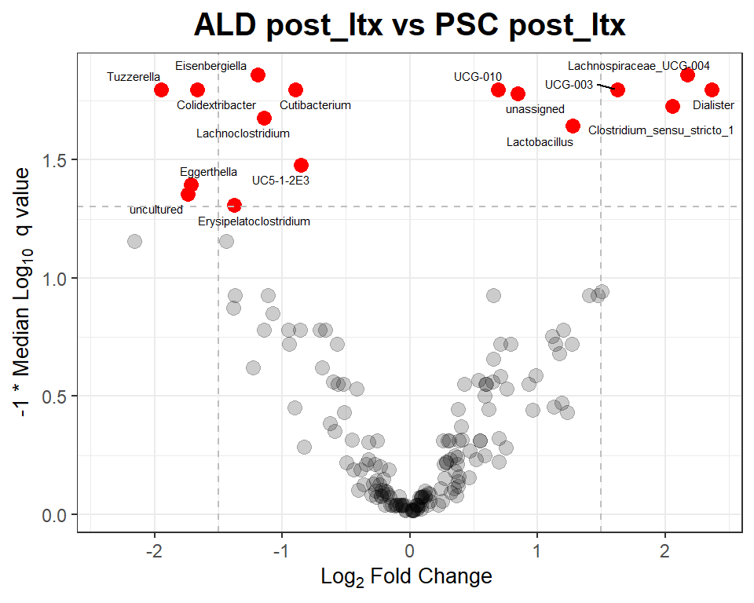

```r
# volcano plot
volcano <- volcano_plot_linda(linda.output, group1,
                                taxa_table = filt_colon_uni_taxa) +
            ggtitle(paste(group,collapse=" vs "))


# see the plot
volcano
```

###### 4.1.0.0.1.2 MaAsLin2

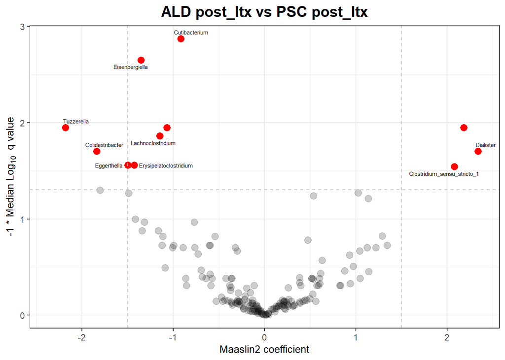

```r
volcano <- volcano_plot_maaslin(fit_data,filt_colon_uni_taxa) +
            ggtitle(paste(group[1], "vs", group[2]))

volcano
```

###### 4.1.0.0.1.3 Group - Intersection

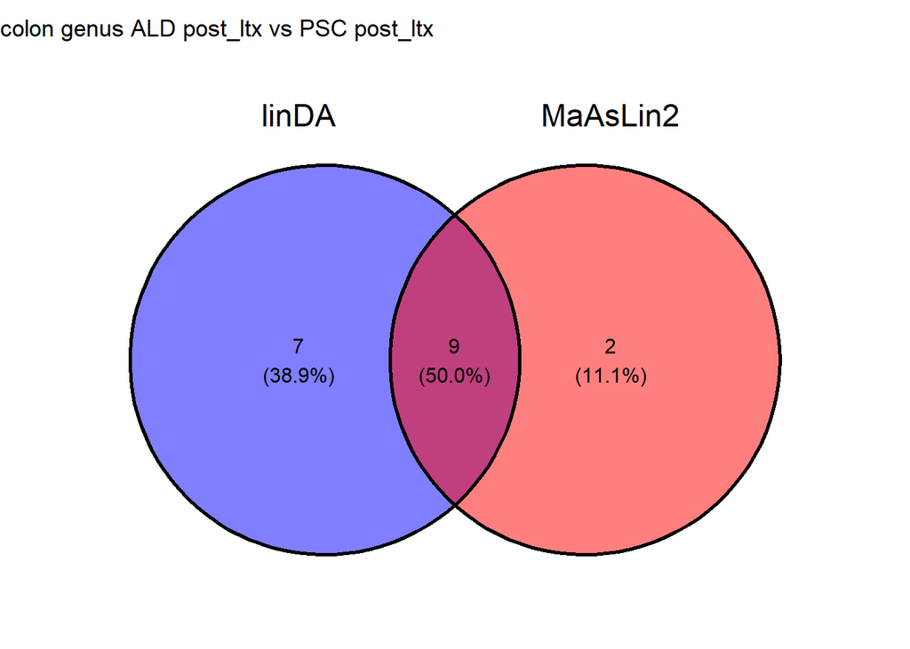

```r
intersection_results <- group_intersection(group, list_intersections, list_venns,
                                           linda.output, fit_data,
                                           raw_linda_results_genus,
                                           segment = segment,
                                           level=level)

list_intersections <- intersection_results[[1]]
list_venns <- intersection_results[[2]]
venn <- intersection_results[[3]]

# show the results
venn
```

###### 4.1.0.0.1.4 Basic statistics

```r
uni_df <-  merge(basic_univariate_statistics(linda_data,group),
                 raw_linda_results_genus[[segment]][[group1]],
                 by="SeqID",all=TRUE)
```

```
[1] "ALD post_ltx"
[1] "PSC post_ltx"
[1] "ALD post_ltx"
[1] "PSC post_ltx"
```

```r
uni_df[["final_sig"]] <- uni_df$SeqID %in% list_intersections[[paste(segment,level,comparison_name)]][["SeqID"]]
uni_statistics[[segment]][[paste(level,comparison_name)]] <- uni_df

# for comparison
new_name <- comparison_name
addWorksheet(wb, sheetName = new_name)
writeData(wb, sheet = new_name, uni_df, rowNames=FALSE)
```

###### 4.1.0.0.1.5 Comparison with PSC-associated taxa

```r
psc_ald_sig_colon <- uni_df %>%
  dplyr::filter(final_sig==TRUE) %>%
  dplyr::select(SeqID,Taxonomy,log2FoldChange)

psc_genus_colon <- psc_genus_colon
```

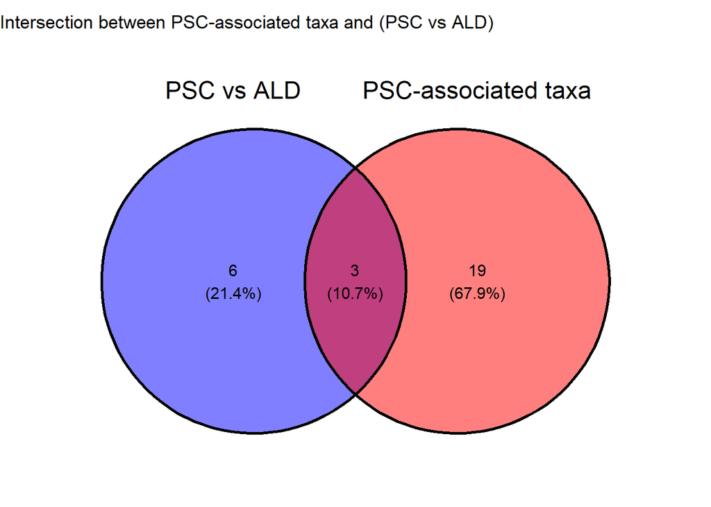

```r
list_core <- list()
list_core[["PSC vs ALD"]] <- psc_ald_sig_colon$Taxonomy
list_core[["PSC-associated taxa"]] <- psc_genus_colon$Taxonomy

# venn diagram
venn <- ggvenn(list_core, fill_color = c("blue", "red")) +
    ggtitle("Intersection between PSC-associated taxa and (PSC vs ALD)") +
    guides(fill = "none")

venn
```

```r
intersection_df <- intersect(list_core$`PSC vs ALD`,list_core$`PSC-associated taxa`)

intersection_df
```

```
[1] "k__Bacteria;p__Firmicutes;c__Clostridia;o__Oscillospirales;f__Oscillospiraceae;g__Colidextribacter"
[2] "k__Bacteria;p__Firmicutes;c__Negativicutes;o__Veillonellales-Selenomonadales;f__Veillonellaceae;g__Dialister"
[3] "k__Bacteria;p__Firmicutes;c__Clostridia;o__Lachnospirales;f__Lachnospiraceae;g__Lachnoclostridium"
```

##### 4.1.0.0.2 ALD vs HC

###### 4.1.0.0.2.1 linDA

```r
group <- c("HC","ALD post_ltx")
comparison_name <- paste0(group[1], " vs ",group[2])
```

```r
# prepare the data
linda_data <- binomial_prep(colon_genus_tab,
                            colon_genus_taxa_tab,
                            colon_metadata,
                            group, usage="linDA")
```

```
Removing 100 ASV(s)
```

```r
filt_colon_uni_data <- linda_data[[1]]
filt_colon_uni_taxa <- linda_data[[2]]
filt_colon_uni_metadata <- linda_data[[3]]

# fit the model
linda.obj <- linda(filt_colon_uni_data,
                   filt_colon_uni_metadata,
                   formula = '~ Group + (1|Patient)')
```

```
0  features are filtered!
The filtered data has  187  samples and  186  features will be tested!
Imputation approach is used.
Fit linear mixed effects models ...
Completed.
```

```r
linda.output <- linda.obj$output
linda.output <- linda_renaming(linda.output, group)

# save the results
group1 <- paste0(group[1], " vs ","Group",group[2])

for (grp in c(group1)){
  raw_linda_results_genus[[segment]][[grp]] <-
    rawlinda.df(linda.output,
                grp,
                filt_colon_uni_data,
                filt_colon_uni_taxa)

  linda_results_genus[[segment]][[grp]] <-
    linda.df(linda.output,
             grp,
             filt_colon_uni_data,
             filt_colon_uni_taxa)
}
```

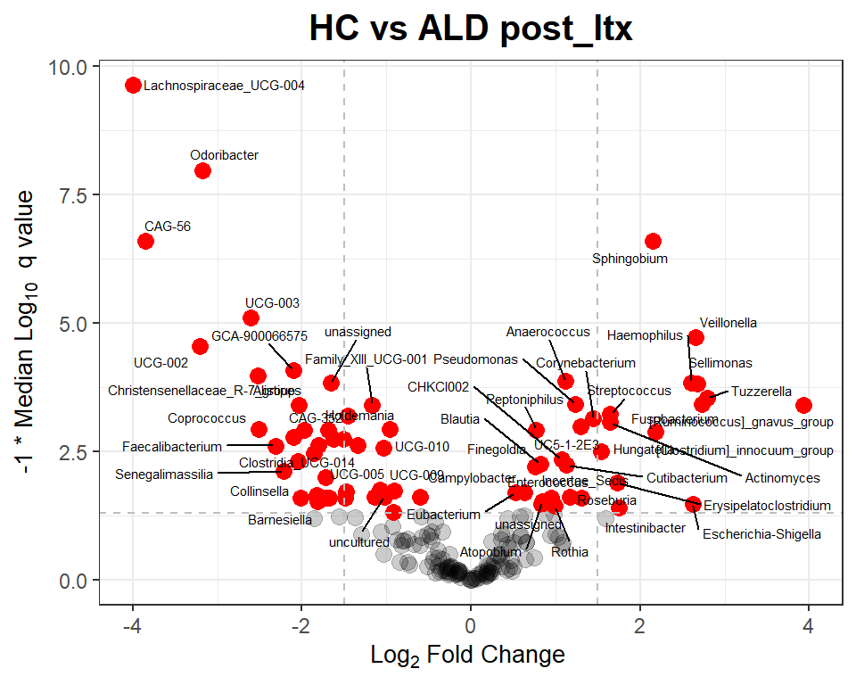

```r
# volcano plot
volcano <- volcano_plot_linda(linda.output, group1,
                                taxa_table = filt_colon_uni_taxa) +
            ggtitle(paste(group,collapse=" vs "))


# see the plot
volcano
```

###### 4.1.0.0.2.2 MaAsLin2

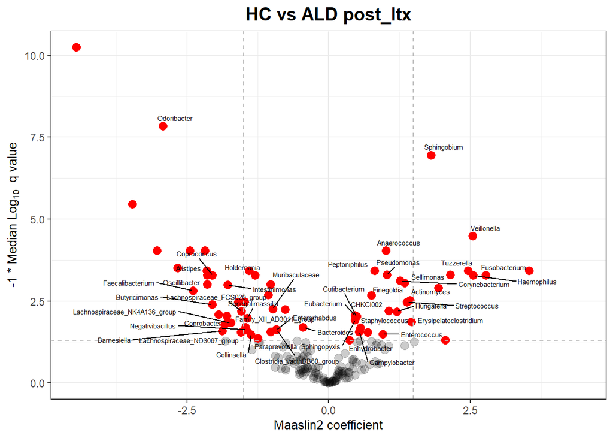

```r
volcano <- volcano_plot_maaslin(fit_data,filt_colon_uni_taxa) +
            ggtitle(paste(group[1], "vs", group[2]))

volcano
```

###### 4.1.0.0.2.3 Group - Intersection

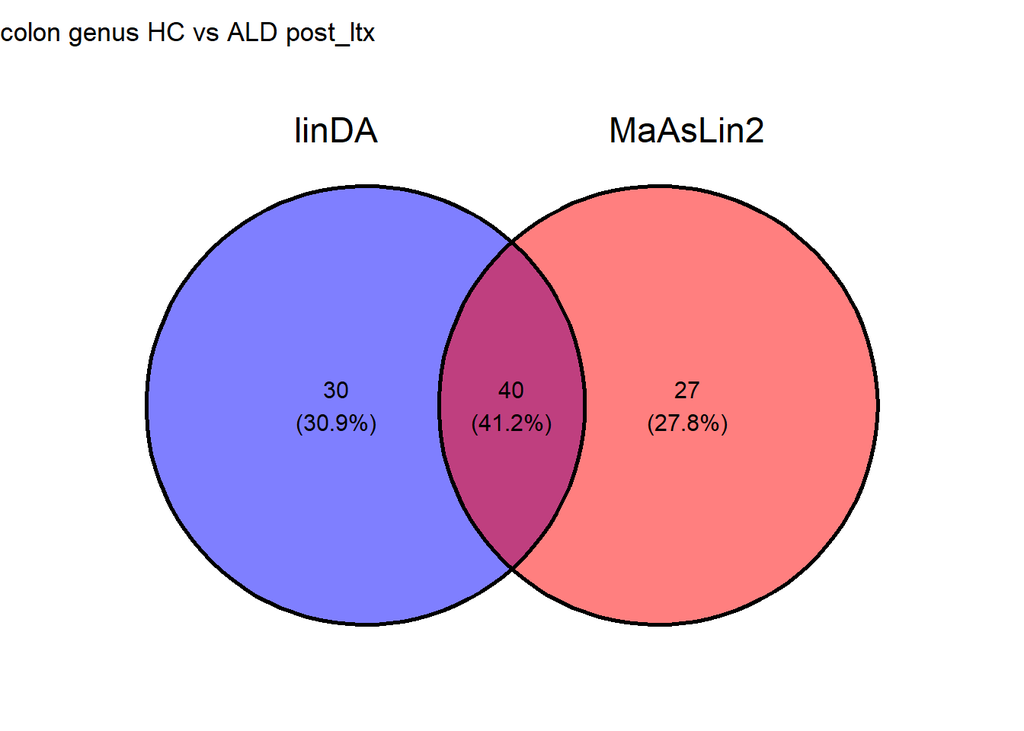

```r
intersection_results <- group_intersection(group, list_intersections, list_venns,
                                           linda.output, fit_data,
                                           raw_linda_results_genus,
                                           segment = segment,
                                           level=level)

list_intersections <- intersection_results[[1]]
list_venns <- intersection_results[[2]]
venn <- intersection_results[[3]]

# show the results
venn
```

###### 4.1.0.0.2.4 Basic statistics

```r
uni_df <-  merge(basic_univariate_statistics(linda_data,group),
                 raw_linda_results_genus[[segment]][[group1]],
                 by="SeqID",all=TRUE)
```

```
[1] "HC"
[1] "ALD post_ltx"
[1] "HC"
[1] "ALD post_ltx"
```

```r
uni_df[["final_sig"]] <- uni_df$SeqID %in% list_intersections[[paste(segment,level,comparison_name)]][["SeqID"]]
uni_statistics[[segment]][[paste(level,comparison_name)]] <- uni_df

# for comparison
new_name <- comparison_name
addWorksheet(wb, sheetName = new_name)
writeData(wb, sheet = new_name, uni_df, rowNames=FALSE)
```

###### 4.1.0.0.2.5 Comparison with PSC-associated taxa

```r
hc_ald_sig_colon <- uni_df %>%
  dplyr::filter(final_sig==TRUE) %>%
  dplyr::select(SeqID,Taxonomy,log2FoldChange)

psc_genus_colon <- psc_genus_colon
```

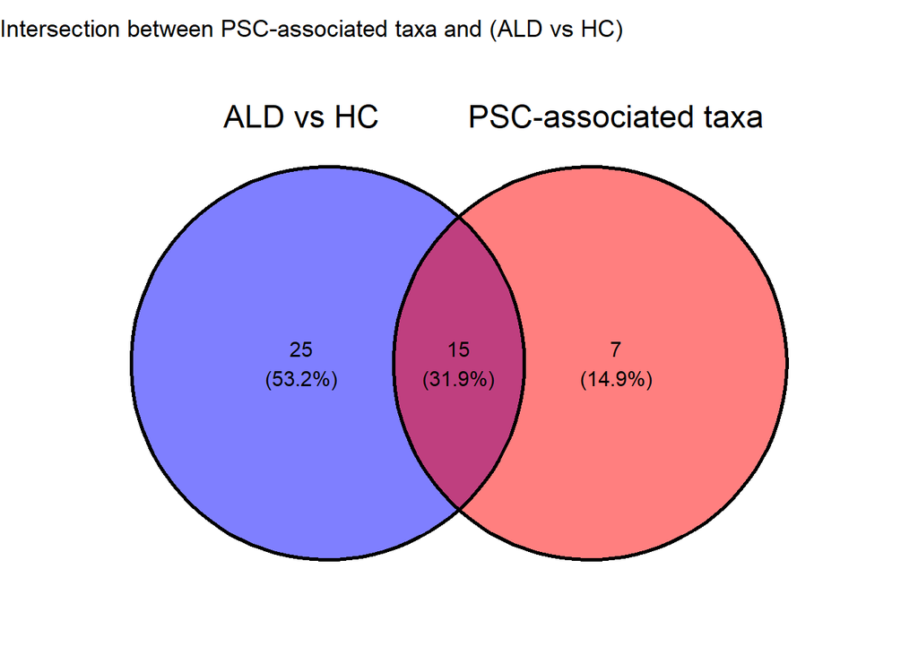

```r
list_core <- list()
list_core[["ALD vs HC"]] <- hc_ald_sig_colon$Taxonomy
list_core[["PSC-associated taxa"]] <- psc_genus_colon$Taxonomy

# venn diagram
venn <- ggvenn(list_core, fill_color = c("blue", "red")) +
    ggtitle("Intersection between PSC-associated taxa and (ALD vs HC)") +
    guides(fill = "none")

venn
```

From this Venn diagram, we are interested in EXLUSIVE RIGH JOIN

```r
A <- list_core$`ALD vs HC`
B <- list_core$`PSC-associated taxa`
remaining_psc <- B[!(B %in% A)]

psc_genus_colon %>%
  dplyr::filter(Taxonomy %in% remaining_psc)
```

```
              SeqID
1            Rothia
2   Parabacteroides
3  Fusicatenibacter
4 Lachnoclostridium
5  Colidextribacter
6         Dialister
7        Klebsiella
                                                                                                      Taxonomy
1               k__Bacteria;p__Actinobacteriota;c__Actinobacteria;o__Micrococcales;f__Micrococcaceae;g__Rothia
2             k__Bacteria;p__Bacteroidota;c__Bacteroidia;o__Bacteroidales;f__Tannerellaceae;g__Parabacteroides
3             k__Bacteria;p__Firmicutes;c__Clostridia;o__Lachnospirales;f__Lachnospiraceae;g__Fusicatenibacter
4            k__Bacteria;p__Firmicutes;c__Clostridia;o__Lachnospirales;f__Lachnospiraceae;g__Lachnoclostridium
5           k__Bacteria;p__Firmicutes;c__Clostridia;o__Oscillospirales;f__Oscillospiraceae;g__Colidextribacter
6 k__Bacteria;p__Firmicutes;c__Negativicutes;o__Veillonellales-Selenomonadales;f__Veillonellaceae;g__Dialister
7 k__Bacteria;p__Proteobacteria;c__Gammaproteobacteria;o__Enterobacterales;f__Enterobacteriaceae;g__Klebsiella
  log2FoldChange      p_value         padj
1       1.842842 1.452081e-05 1.953709e-04
2      -3.568149 2.950689e-06 6.238599e-05
3      -1.917547 1.097200e-02 3.455012e-02
4      -1.736481 1.812625e-03 8.383390e-03
5      -1.624469 8.895010e-03 2.991958e-02
6       2.144460 1.055678e-02 3.396528e-02
7       2.288824 1.471023e-03 7.257045e-03
```

```r
uni_df %>%
  dplyr::filter(Taxonomy %in% remaining_psc)
```

```
              SeqID Q1_clr HC Q1_clr ALD post_ltx     Q1_ra HC
1  Colidextribacter  1.386414           1.3243781 0.0006398704
2         Dialister -2.055467          -1.8464644 0.0000000000
3  Fusicatenibacter  2.627958          -0.9536309 0.0024423570
4        Klebsiella -2.173923          -2.1627708 0.0000000000
5 Lachnoclostridium  4.526164           4.3276317 0.0163044634
6   Parabacteroides  3.207395           1.7713357 0.0044359835
7            Rothia -2.019276          -1.6659988 0.0000000000
  Q1_ra ALD post_ltx MEDIAN_clr HC MEDIAN_clr ALD post_ltx MEDIAN_clr_ALL
1       0.0005364459     2.1904872               2.6123898      2.4197662
2       0.0000000000    -1.6466225              -1.5459890     -1.5933847
3       0.0000000000     3.7263000               3.4597865      3.6125117
4       0.0000000000    -1.9014687              -1.7576714     -1.8353611
5       0.0098512164     5.0769310               4.9156184      5.0561821
6       0.0005008488     3.8462676               3.5515723      3.7260301
```

[output cut: 57 more lines]